# Ciliated expression in low/high grade SOC

Zhiyuan Hu

25/02/2020 (last modified: 2020-05-23)

# Summary

This script aims to study the prediction power of expression of cilited markers on the subtyping of high-grade and low-grade serous ovarian tumours.

We performed the IHC on tissue arrays with CCDC17 and CAPS antibody. The tissue arrays were scanned with Aperio Slide Scanner and the expression scores were measured by the quPath software. Here, I will use logistic model and cross-validate to evaluate if the expression of CAPS and CCDC17 can predic the low-grade and high-grade tumours.

# CAPS IHC data

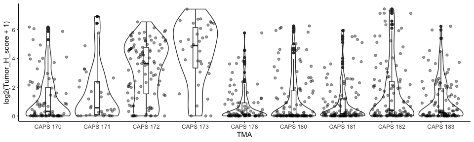

Distribution of CAPS scores in TMAs

```r
df_caps <- read.csv("../../Ciliated_grade/CAPS TMA 19.7.2019.csv", as.is = T)
df_caps$TMA[df_caps$TMA == "TA 172"] <- "CAPS 172"
colnames(df_caps) <- gsub(pattern = "[..]", replacement = "_", x = colnames(df_caps))
colnames(df_caps) <- gsub(pattern = "__", replacement = "_", x = colnames(df_caps))

df_caps$ratio_tumour_1 <- df_caps$Num_Tumor_1_/df_caps$Num_Tumor
df_caps$ratio_tumour_2 <- df_caps$Num_Tumor_2_/df_caps$Num_Tumor
df_caps$ratio_tumour_3 <- df_caps$Num_Tumor_3_/df_caps$Num_Tumor

ggplot(df_caps, aes(x = TMA, y = log2(Tumor_H_score + 1))) +
    geom_violin(scale = "width")  + geom_boxplot(width = 0.1) +
    geom_jitter(alpha = 0.4) + theme_classic()
```

There are outliers in CAPS 182

I will remove 180, 181, 182 from the analysis, as they were not defined as high-grade serous on the record to tissue arrays.

```r
# filter out some TMAs
df_caps <- df_caps[df_caps$TMA %in% c("CAPS 170", "CAPS 171", "CAPS 172", "CAPS 173", "CAPS 178", "CAPS 183"),]
table(df_caps$tumor_type)
```

```
##
##   0   1
## 141 330
```

We will use the logistic regression as shown in the below

$$\log(\frac{p(x)}{1-p(x)})=\beta_{0}+\beta_{1}x_{1}+\beta_{2}x_{2}+\beta_{3}x_{3}$$

https://daviddalpiaz.github.io/r4sl/logistic-regression.html#logistic-regression-with-glm

in which the $x$ is whether the tumour is low or high grade. $x_1$, $x_2$ and $x_3$ represents the proportion of tumour cells expressing CAPS at +, ++ and +++.

## ROC (Receiver operating characteristic) curve

```r
set.seed(34521)
idx <- createDataPartition(df_caps$tumor_type, times = 2, p = 0.6)
```

```r
training_dt <- df_caps[idx$Resample1,]
testing_dt <- df_caps[-idx$Resample1,]

## Logistic regression
model_glm = glm(tumor_type ~ ratio_tumour_1 + ratio_tumour_2 + ratio_tumour_3, data = training_dt, family = "binomial")
model_glm_pred = ifelse(predict(model_glm, type = "link") > 0, 1, 0)

train_tab = table(predicted = model_glm_pred, actual = training_dt$tumor_type)

train_con_mat = caret::confusionMatrix(train_tab)
c(train_con_mat$overall["Accuracy"],
  train_con_mat$byClass["Sensitivity"],
  train_con_mat$byClass["Specificity"])
```

```
##    Accuracy Sensitivity Specificity
##   0.8056537   0.4457831   0.9550000
```

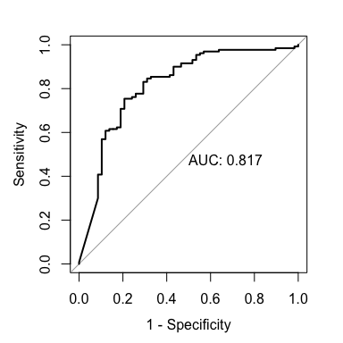

```
##
## Call:
## roc.default(response = testing_dt$tumor_type, predictor = test_prob,     plot = TRUE, print.auc = TRUE, legacy.axes = TRUE)
##
## Data: test_prob in 58 controls (testing_dt$tumor_type 0) < 130 cases (testing_dt$tumor_type 1).
## Area under the curve: 0.817
```

```r
# ROC
test_prob = predict(model_glm, newdata = testing_dt, type = "response")
# pdf("plots/IHC_CAPS_ROC_20200508.pdf")
roc(testing_dt$tumor_type, test_prob, plot = TRUE, print.auc = TRUE, legacy.axes=TRUE)
```

```r
# dev.off()
```

## Cross validation

```r
set.seed(34521)
idx <- createFolds(df_caps$tumor_type, k = 8)
```

```r
test_roc_list <- list()
model_list <- list()

for(itor in 1:length(idx)) {

    training_dt <- df_caps[-idx[[itor]],]
    testing_dt <- df_caps[idx[[itor]],]

    ## Logistic regression
    model_glm = glm(tumor_type ~ ratio_tumour_1 + ratio_tumour_2 + ratio_tumour_3, data = training_dt, family = "binomial")
    model_list[[itor]] <- model_glm

    # ROC
    test_prob <- predict(model_glm, newdata = testing_dt, type = "response")
    test_roc_list[[itor]] <- roc(testing_dt$tumor_type ~ test_prob, plot = F, print.auc = F)
}
```

```r
model_list[[5]]$coefficients
```

```
##    (Intercept) ratio_tumour_1 ratio_tumour_2 ratio_tumour_3
##      1.5595997    -10.4186550     -0.9434346      3.0548552
```

Distribution of AUC values

```r
# distribution of AUCs
sapply(test_roc_list, function(x) return(x$auc))
```

```
## [1] 0.7911548 0.6659091 0.8565789 0.8059524 0.9090909 0.7605042 0.8612040
## [8] 0.8515152
```

```r
median(sapply(test_roc_list, function(x) return(x$auc)))
```

```
## [1] 0.8287338
```

# CCDC17

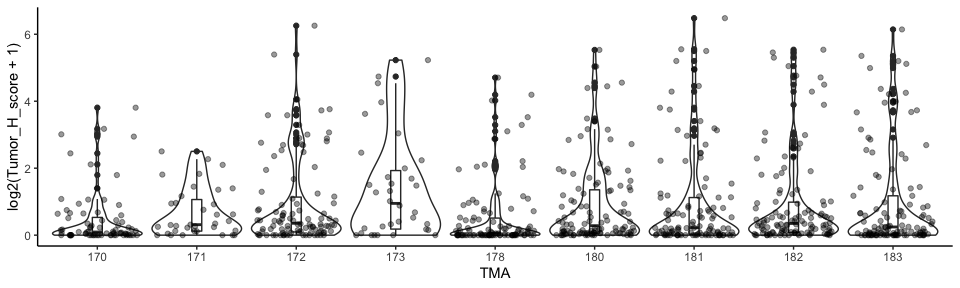

Distribution of CCDC17 scores in TMAs

```r
df_CCDC17 <- read.csv("../../Ciliated_grade/CCDC17 TMA 23.03.2020.csv", as.is = T)
colnames(df_CCDC17) <- gsub(pattern = "[..]", replacement = "_", x = colnames(df_CCDC17))
colnames(df_CCDC17) <- gsub(pattern = "__", replacement = "_", x = colnames(df_CCDC17))

df_CCDC17$ratio_tumour_1 <- df_CCDC17$Num_Tumor_1_/df_CCDC17$Num_Tumor
df_CCDC17$ratio_tumour_2 <- df_CCDC17$Num_Tumor_2_/df_CCDC17$Num_Tumor
df_CCDC17$ratio_tumour_3 <- df_CCDC17$Num_Tumor_3_/df_CCDC17$Num_Tumor

df_CCDC17$TMA <- as.factor(df_CCDC17$TMA)

ggplot(df_CCDC17, aes(x = TMA, y = log2(Tumor_H_score + 1))) +
    geom_violin(scale = "width")  + geom_boxplot(width = 0.1) +
    geom_jitter(alpha = 0.4)+ theme_classic()
```

```r
df_CCDC17 <- df_CCDC17[df_CCDC17$TMA %in% c("170", "171", "172", "173", "178", "183"),]
table(df_CCDC17$tumor_type)
```

```
##
##   0   1
## 128 338
```

## ROC (Receiver operating characteristic) curve

```r
set.seed(34521)
idx <- createDataPartition(df_CCDC17$tumor_type, times = 2, p = 0.6)
```

```r
training_dt <- df_CCDC17[idx$Resample1,]
testing_dt <- df_CCDC17[-idx$Resample1,]

## Logistic regression
model_glm = glm(tumor_type ~ ratio_tumour_1 + ratio_tumour_2 + ratio_tumour_3, data = training_dt, family = "binomial")
model_glm_pred = ifelse(predict(model_glm, type = "link") > 0, 1, 0)

train_tab = table(predicted = model_glm_pred, actual = training_dt$tumor_type)

train_con_mat = caret::confusionMatrix(train_tab)
c(train_con_mat$overall["Accuracy"],
  train_con_mat$byClass["Sensitivity"],
  train_con_mat$byClass["Specificity"])
```

```
##    Accuracy Sensitivity Specificity
##  0.72857143  0.03947368  0.98529412
```

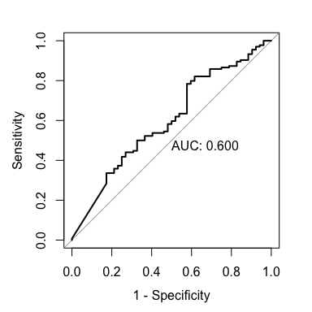

```
##
## Call:
## roc.default(response = testing_dt$tumor_type, predictor = test_prob,     plot = TRUE, print.auc = TRUE, legacy.axes = TRUE)
##
## Data: test_prob in 52 controls (testing_dt$tumor_type 0) < 134 cases (testing_dt$tumor_type 1).
## Area under the curve: 0.5997
```

```r
# ROC
test_prob = predict(model_glm, newdata = testing_dt, type = "response")
roc(testing_dt$tumor_type, test_prob, plot = TRUE, print.auc = TRUE, legacy.axes=TRUE)
```

## Cross validation

```r
set.seed(34521)
idx <- createFolds(df_CCDC17$tumor_type, k = 8)

test_roc_list <- list()
model_list <- list()

for(itor in 1:length(idx)) {

    training_dt <- df_CCDC17[-idx[[itor]],]
    testing_dt <- df_CCDC17[idx[[itor]],]



    ## Logistic regression
    model_glm = glm(tumor_type ~ ratio_tumour_1 + ratio_tumour_2 + ratio_tumour_3, data = training_dt, family = "binomial")
    model_list[[itor]] <- model_glm

    # ROC
    test_prob <- predict(model_glm, newdata = testing_dt, type = "response")
    test_roc_list[[itor]] <- roc(testing_dt$tumor_type ~ test_prob, plot = F, print.auc = F)
}
```

```r
# distribution of AUCs
sapply(test_roc_list, function(x) return(x$auc))
```

```
## [1] 0.5282738 0.6183644 0.4732919 0.6435006 0.4602273 0.5793651 0.6666667
## [8] 0.5476190
```

```r
median(sapply(test_roc_list, function(x) return(x$auc)))
```

```
## [1] 0.5634921
```

# Conclusions

- CAPS IHC achieved a high AUC value for the cross validation, which is over 0.8
- CCDC17 IHC is not ideal as the median of its AUC values is only around 0.56